# TensorQTL report

Darren Cameron

2026-03-17

## TensorQTL pipeline steps

We used [tensorQTL](https://github.com/broadinstitute/tensorqtl) to generate eQTL. The citation for tensorQTL is [Taylor-Weiner et al. 2019 (DOI:10.1186/s13059-019-1836-7)](https://genomebiology.biomedcentral.com/articles/10.1186/s13059-019-1836-7).

1. `prep_tensorQTL_input`: Munge cell-specific pseudobulk gExp and covaraiate data into TensorQTL-ready format
2. `zip_pblk_cnts`: bgzip and index pseudobulk gExp data
3. `convert_genotypes`: Convert genotypes into into TensorQTL-ready plink 2 format
4. `split_covariates`: Generate covaraiate files for gene_pc and exp_pc combinations
5. `tensorqtl_nom`: Run TensorQTL to detect cis-eQTL nominal p-values
6. `tensorqtl_perm`: Run TensorQTL to detect cis-eQTL via permutations
7. `tensorqtl_independent`: Run TensorQTL to detect conditionally independent variants
8. `tensorqtl_trans`: Run TensorQTL to detect trans-eQTL

Sensitivity settings:

- cis-window: $\pm$ 500kb
- Expression PC covariates tested: 10, 20, 30, 40, 50
- Meta data covariates: PCW, sex
- Genotype PCs: 4 (see genotyping_post_impute_report.html)
- Norm methods tested: bryois, fugita, quantile, xue

### Level 1

#### Sensitivity

##### Plot

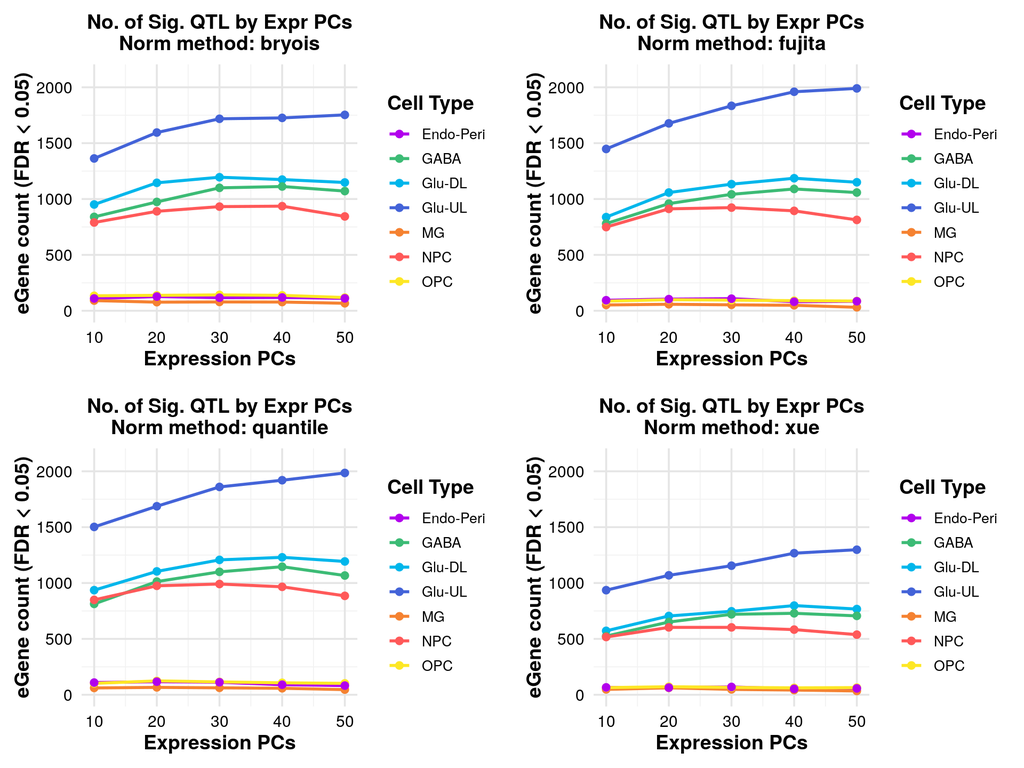

##### Table (best)

Table 1. Best param configuration per cell type

| Cell Type | Expression PCs | Normalisation method | No. of eGenes |
| --- | --- | --- | --- |
| Endo-Peri | 20 | bryois | 127 |
| GABA | 40 | quantile | 1146 |
| Glu-DL | 40 | quantile | 1230 |
| Glu-UL | 50 | fujita | 1990 |
| MG | 10 | bryois | 91 |
| NPC | 30 | quantile | 991 |
| OPC | 30 | bryois | 142 |

##### Table (all)

Table 2. All param configurations

| Expression PCs | Normalisation method | Endo-Peri | GABA | Glu-DL | Glu-UL | MG | NPC | OPC |
| --- | --- | --- | --- | --- | --- | --- | --- | --- |
| 50 | bryois | 111 | 1071 | 1148 | 1753 | 67 | 844 | 118 |
| 50 | fujita | 85 | 1058 | 1150 | 1990 | 31 | 813 | 87 |
| 50 | quantile | 82 | 1067 | 1193 | 1985 | 46 | 885 | 102 |
| 50 | xue | 57 | 706 | 767 | 1298 | 34 | 538 | 64 |
| 40 | bryois | 119 | 1112 | 1174 | 1726 | 78 | 936 | 138 |
| 40 | fujita | 81 | 1090 | 1186 | 1960 | 49 | 894 | 90 |
| 40 | quantile | 90 | 1146 | 1230 | 1920 | 58 | 966 | 107 |
| 40 | xue | 53 | 729 | 798 | 1267 | 42 | 583 | 62 |
| 30 | bryois | 117 | 1100 | 1195 | 1718 | 79 | 932 | 142 |
| 30 | fujita | 108 | 1042 | 1133 | 1834 | 53 | 923 | 95 |
| 30 | quantile | 112 | 1100 | 1207 | 1860 | 62 | 991 | 115 |
| 30 | xue | 70 | 720 | 747 | 1155 | 48 | 603 | 66 |
| 20 | bryois | 127 | 974 | 1145 | 1595 | 77 | 890 | 138 |
| 20 | fujita | 104 | 959 | 1058 | 1677 | 58 | 912 | 99 |
| 20 | quantile | 117 | 1013 | 1104 | 1687 | 66 | 975 | 124 |
| 20 | xue | 64 | 651 | 705 | 1069 | 62 | 603 | 72 |
| 10 | bryois | 110 | 840 | 951 | 1363 | 91 | 790 | 134 |
| 10 | fujita | 94 | 780 | 838 | 1448 | 52 | 749 | 86 |
| 10 | quantile | 109 | 813 | 936 | 1502 | 61 | 849 | 102 |
| 10 | xue | 66 | 525 | 572 | 936 | 48 | 517 | 64 |

#### Density plot

##### Individual

- Showing plots for geno PCs = 4, Exp PCs = `expPC_map`, norm method = ‘quantile’

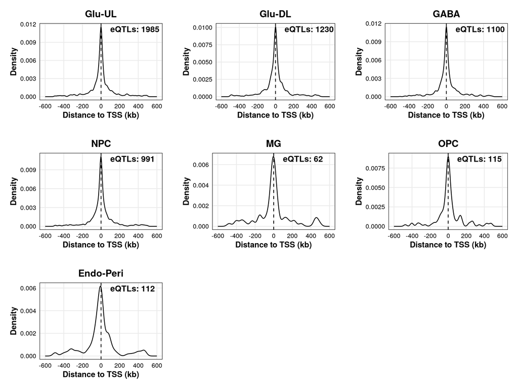

##### Combined

- Showing plots for geno PCs = 4, Exp PCs = `expPC_map`, norm method = ‘quantile’

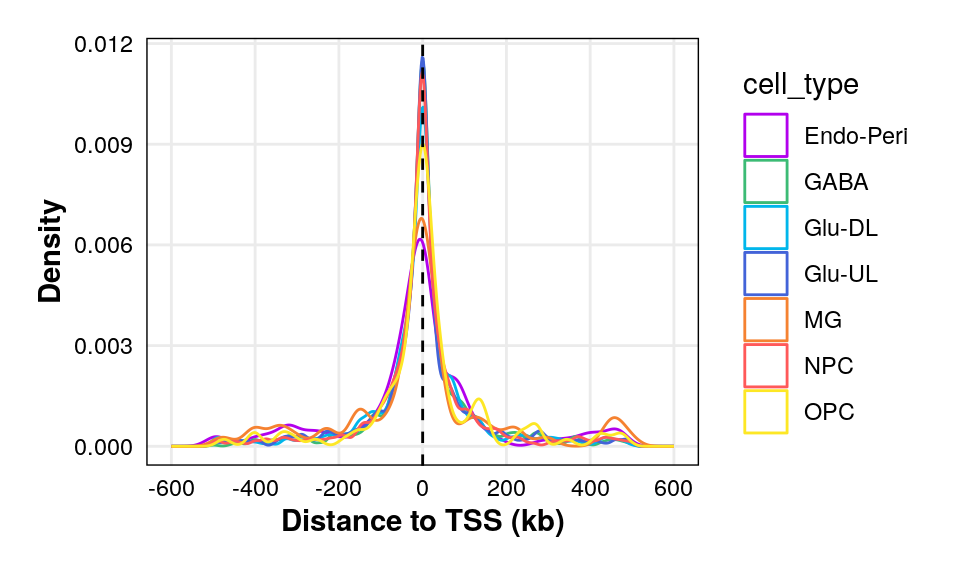

#### Pie Chart

- Showing plots for geno PCs = 4, Exp PCs = `expPC_map`, norm method = ‘quantile’

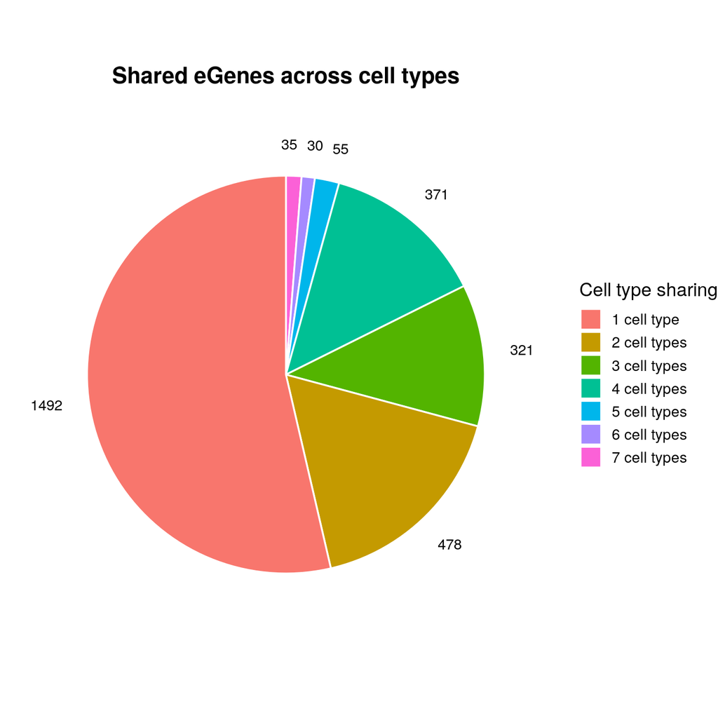

#### Counts

- Showing plots for geno PCs = 4, Exp PCs = `expPC_map`, norm method = ‘quantile’

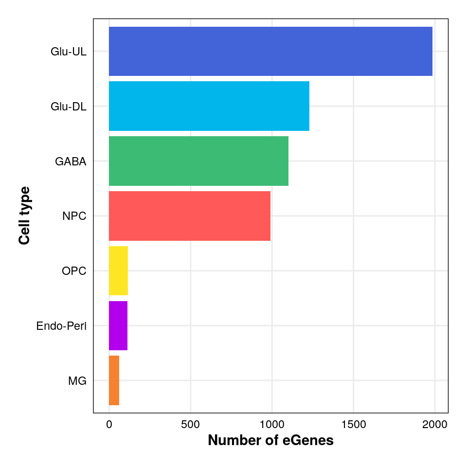

#### Upset

- Showing plots for geno PCs = 4, Exp PCs = `expPC_map`, norm method = ‘quantile’

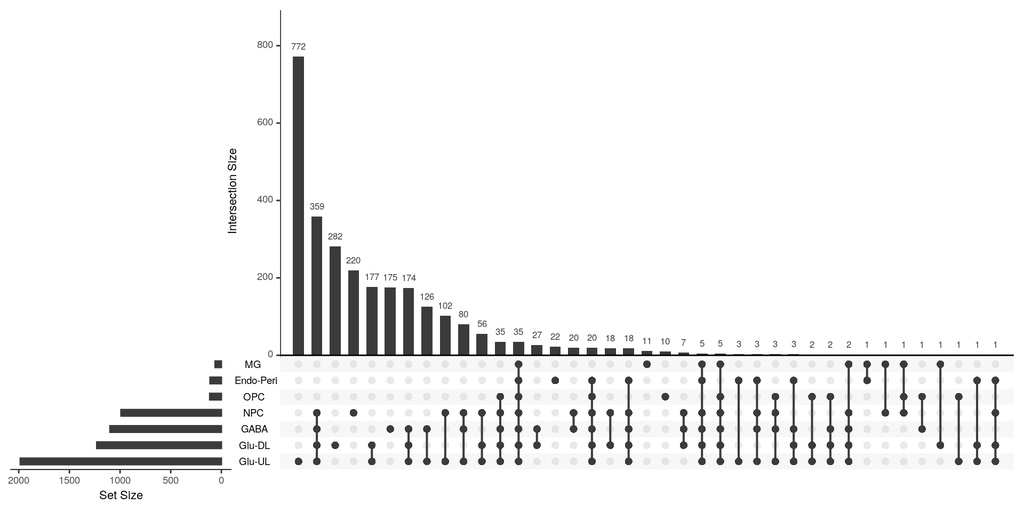

#### Scatter

- Showing plots for geno PCs = 4, Exp PCs = `expPC_map`, norm method = ‘quantile’

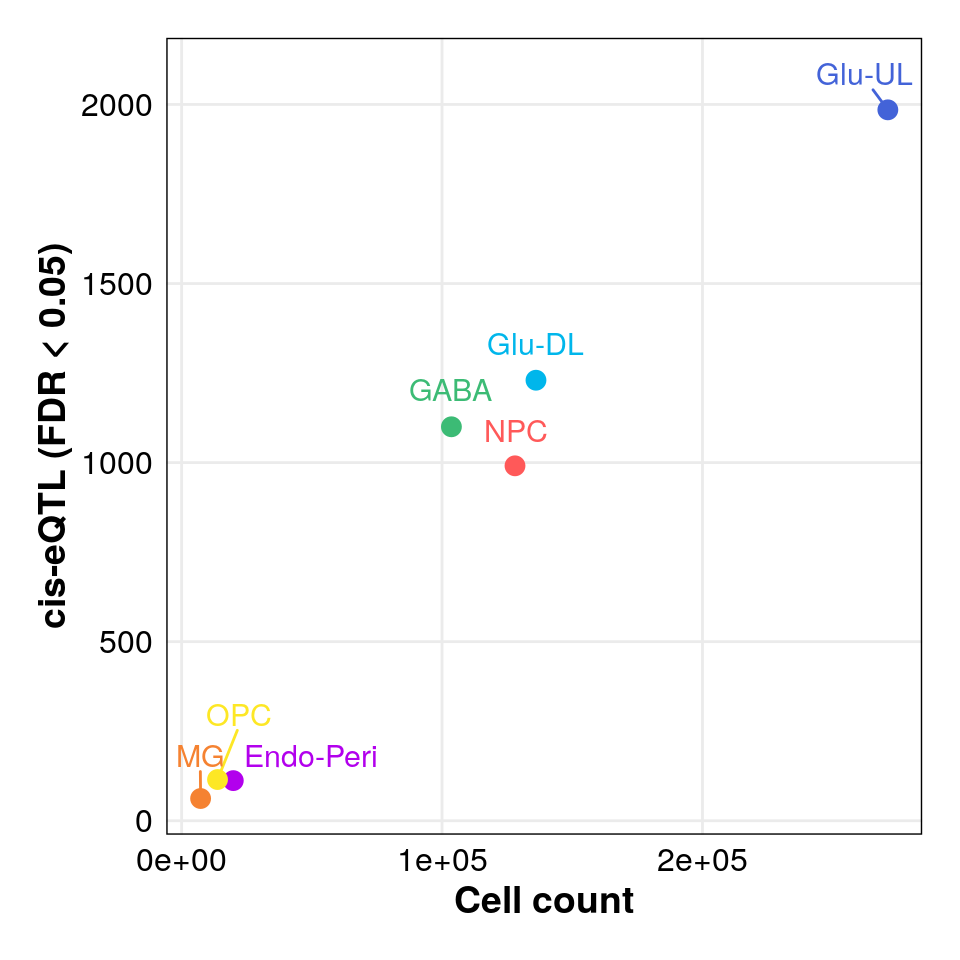

#### Settings

- Showing plots for geno PCs = 4, Exp PCs = `expPC_map`, norm method = ‘quantile’

Table 3. TensorQTL, inputs per cell type

| Cell Type | Genes Tested | Samples | Variants |
| --- | --- | --- | --- |
| Endo-Peri | 19,666 | 134 | 5,794,957 |
| GABA | 19,133 | 134 | 5,794,957 |
| Glu-DL | 19,056 | 134 | 5,794,957 |
| Glu-UL | 17,609 | 134 | 5,794,957 |
| MG | 19,668 | 134 | 5,794,957 |
| NPC | 19,086 | 134 | 5,794,957 |
| OPC | 19,663 | 134 | 5,794,957 |

#### Independent

##### Counts

- Showing tables for geno PCs = 4, Exp PCs = `expPC_map`, norm method = ‘quantile’

Table 4. Independent eQTL counts per cell type

| Cell Type | Primary eQTL | Secondary eQTL | Tertiary eQTL |
| --- | --- | --- | --- |
| Endo-Peri | 112 | 3 | 0 |
| GABA | 1,100 | 44 | 1 |
| Glu-DL | 1,230 | 56 | 1 |
| Glu-UL | 1,985 | 120 | 3 |
| MG | 62 | 1 | 0 |
| NPC | 991 | 48 | 1 |
| OPC | 115 | 2 | 0 |

##### Distance from TSS

- Showing tables for geno PCs = 4, Exp PCs = `expPC_map`, norm method = ‘quantile’

Table 5. Median TSS distances (kb) for independent eQTLs per cell type

| Cell Type | Primary eQTL | Secondary eQTL | Tertiary eQTL |
| --- | --- | --- | --- |
| Endo-Peri | 51 | 43 | 0 |
| GABA | 32 | 108 | 398 |
| Glu-DL | 35 | 44 | 1 |
| Glu-UL | 32 | 84 | 153 |
| MG | 37 | 181 | 0 |
| NPC | 34 | 95 | 170 |
| OPC | 35 | 82 | 0 |

##### SNPs

- Showing tables for geno PCs = 4, Exp PCs = `expPC_map`, norm method = ‘quantile’

Table 6. Genes with multiple independent eQTL per cell type

| Cell Type | Gene | Primary SNP | Primary AF | Primary Perm P | Secondary SNP | Secondary AF | Secondary Perm P | Tertiary SNP | Tertiary AF | Tertiary Perm P |
| --- | --- | --- | --- | --- | --- | --- | --- | --- | --- | --- |
| Glu-UL | ENSG00000058453 | rs2761504 | 0.280 | − | rs55779591 | 0.340 | − | NA | NA | NA |
| Glu-UL | ENSG00000001460 | rs2477303 | 0.228 | − | rs195731 | 0.653 | − | NA | NA | NA |
| Glu-UL | ENSG00000134198 | rs755820 | 0.190 | − | rs11466108 | 0.045 | − | NA | NA | NA |
| Glu-UL | ENSG00000236427 | rs12130219 | 0.201 | − | rs61815525 | 0.149 | − | NA | NA | NA |
| Glu-UL | ENSG00000135845 | rs4471302 | 0.231 | − | rs112318001 | 0.056 | − | NA | NA | NA |
| Glu-UL | ENSG00000143801 | rs12143886 | 0.220 | − | rs2236914 | 0.522 | − | NA | NA | NA |
| Glu-UL | ENSG00000305271 | rs6680033 | 0.328 | − | rs2047191 | 0.250 | − | NA | NA | NA |
| Glu-UL | ENSG00000215146 | rs2505811 | 0.366 | − | rs12249048 | 0.134 | − | NA | NA | NA |
| Glu-UL | ENSG00000291065 | rs2505811 | 0.366 | − | rs12249048 | 0.134 | − | NA | NA | NA |
| Glu-UL | ENSG00000185904 | rs2505811 | 0.366 | − | rs678822 | 0.388 | − | NA | NA | NA |
| Glu-UL | ENSG00000107798 | rs304412 | 0.216 | − | rs304411 | 0.190 | − | NA | NA | NA |
| Glu-UL | ENSG00000095574 | rs1341394 | 0.280 | − | rs9423292 | 0.683 | − | NA | NA | NA |
| Glu-UL | ENSG00000287898 | rs77889556 | 0.146 | − | rs61880560 | 0.160 | − | NA | NA | NA |
| Glu-UL | ENSG00000172803 | rs566266 | 0.384 | − | rs12363523 | 0.082 | − | NA | NA | NA |
| Glu-UL | ENSG00000254459 | rs570786 | 0.369 | − | rs598071 | 0.239 | − | NA | NA | NA |
| Glu-UL | ENSG00000309946 | rs2034622 | 0.511 | − | rs7940549 | 0.112 | − | NA | NA | NA |
| Glu-UL | ENSG00000250519 | rs10831169 | 0.433 | − | rs4753548 | 0.448 | − | NA | NA | NA |
| Glu-UL | ENSG00000291189 | rs1860423 | 0.619 | − | rs887356 | 0.896 | − | NA | NA | NA |
| Glu-UL | ENSG00000130035 | rs766505 | 0.563 | − | rs1974621 | 0.765 | − | NA | NA | NA |
| Glu-UL | ENSG00000231887 | rs68186227 | 0.310 | − | rs34423519 | 0.254 | − | NA | NA | NA |
| Glu-UL | ENSG00000134283 | rs4382968 | 0.131 | − | rs4768412 | 0.410 | − | NA | NA | NA |
| Glu-UL | ENSG00000257815 | rs11609337 | 0.142 | − | rs735309 | 0.694 | − | NA | NA | NA |
| Glu-UL | ENSG00000157837 | rs586305 | 0.739 | − | rs73214202 | 0.146 | − | NA | NA | NA |
| Glu-UL | ENSG00000130921 | rs1790097 | 0.836 | − | rs74240770 | 0.060 | − | NA | NA | NA |
| Glu-UL | ENSG00000120693 | rs9566169 | 0.201 | − | rs8000733 | 0.160 | − | NA | NA | NA |
| Glu-UL | ENSG00000123179 | rs9568308 | 0.116 | − | rs3851166 | 0.160 | − | NA | NA | NA |
| Glu-UL | ENSG00000295839 | rs139800603 | 0.049 | − | rs2181267 | 0.157 | − | NA | NA | NA |
| Glu-UL | ENSG00000042317 | rs35823815 | 0.179 | − | rs28482235 | 0.366 | − | NA | NA | NA |
| Glu-UL | ENSG00000258702 | rs75564413 | 0.116 | − | rs72706869 | 0.175 | − | NA | NA | NA |
| Glu-UL | ENSG00000258593 | rs28427389 | 0.556 | − | rs2841219 | 0.567 | − | rs56307141 | 0.414 | NA |

[output cut: 244 more lines]

#### Benchmarking

##### Table

|  | rule | n | mean_runtime_min | sd_runtime_min | mean_ram_gb | sd_ram_gb |
| --- | --- | --- | --- | --- | --- | --- |
| 1 | convert | 1 | 1.825 | 0 | 0.879 | 0 |
| 2 | independent | 143 | 5.127 | 4.065 | 3.718 | 0.173 |
| 3 | nom | 273 | 3.421 | 0.508 | 3.352 | 0.107 |
| 4 | perm | 333 | 108.585 | 15.573 | 3.424 | 0.093 |
| 5 | post | 7 | 0.121 | 0.027 | 0.447 | 0.099 |
| 6 | prep | 77 | 0.546 | 0.13 | 0.489 | 0.174 |
| 7 | split | 333 | 0.086 | 0.055 | 0.14 | 0.001 |
| 8 | tensorqtl | 1 | 0.725 | 0 | 0.284 | 0 |
| 9 | trans | 143 | 29.406 | 4.23 | 8.458 | 0.971 |
| 10 | zip | 77 | 0.073 | 0.013 | 0.018 | 0.003 |

##### Plot

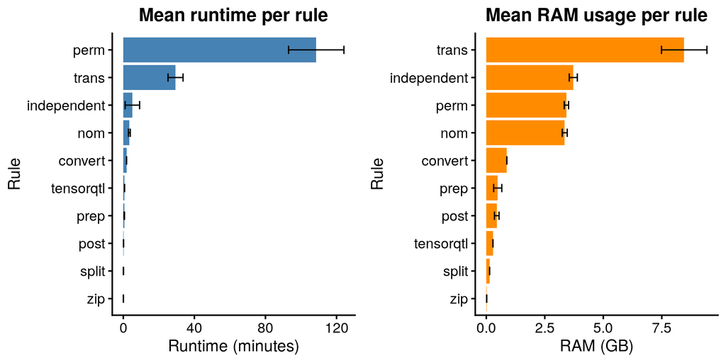

### Level 2

#### Sensitivity

##### Plot

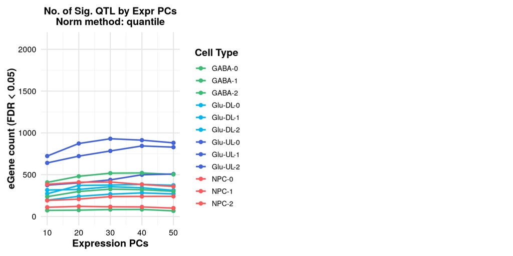

##### Table (best)

Table 1. Best param configuration per cell type

| Cell Type | Expression PCs | Normalisation method | No. of eGenes |
| --- | --- | --- | --- |
| GABA-0 | 30 | quantile | 327 |
| GABA-1 | 40 | quantile | 521 |
| GABA-2 | 40 | quantile | 84 |
| Glu-DL-0 | 40 | quantile | 384 |
| Glu-DL-1 | 40 | quantile | 282 |
| Glu-DL-2 | 30 | quantile | 356 |
| Glu-UL-0 | 30 | quantile | 930 |
| Glu-UL-1 | 50 | quantile | 508 |
| Glu-UL-2 | 40 | quantile | 844 |
| NPC-0 | 50 | quantile | 241 |
| NPC-1 | 30 | quantile | 412 |
| NPC-2 | 20 | quantile | 121 |

##### Table (all)

Table 2. All param configurations

| Expression PCs | Normalisation method | GABA-0 | GABA-1 | GABA-2 | Glu-DL-0 | Glu-DL-1 | Glu-DL-2 | Glu-UL-0 | Glu-UL-1 | Glu-UL-2 | NPC-0 | NPC-1 | NPC-2 |
| --- | --- | --- | --- | --- | --- | --- | --- | --- | --- | --- | --- | --- | --- |
| 50 | quantile | 301 | 503 | 67 | 373 | 270 | 313 | 881 | 508 | 829 | 241 | 359 | 100 |
| 40 | quantile | 321 | 521 | 84 | 384 | 282 | 343 | 913 | 499 | 844 | 240 | 383 | 114 |
| 30 | quantile | 327 | 518 | 83 | 376 | 267 | 356 | 930 | 438 | 784 | 238 | 412 | 116 |
| 20 | quantile | 299 | 481 | 76 | 371 | 241 | 324 | 873 | 402 | 722 | 208 | 410 | 121 |
| 10 | quantile | 237 | 408 | 73 | 272 | 195 | 316 | 723 | 375 | 641 | 192 | 385 | 110 |

#### Density plot

##### Individual

- Showing plots for geno PCs = 4, Exp PCs = `expPC_map`, norm method = ‘quantile’

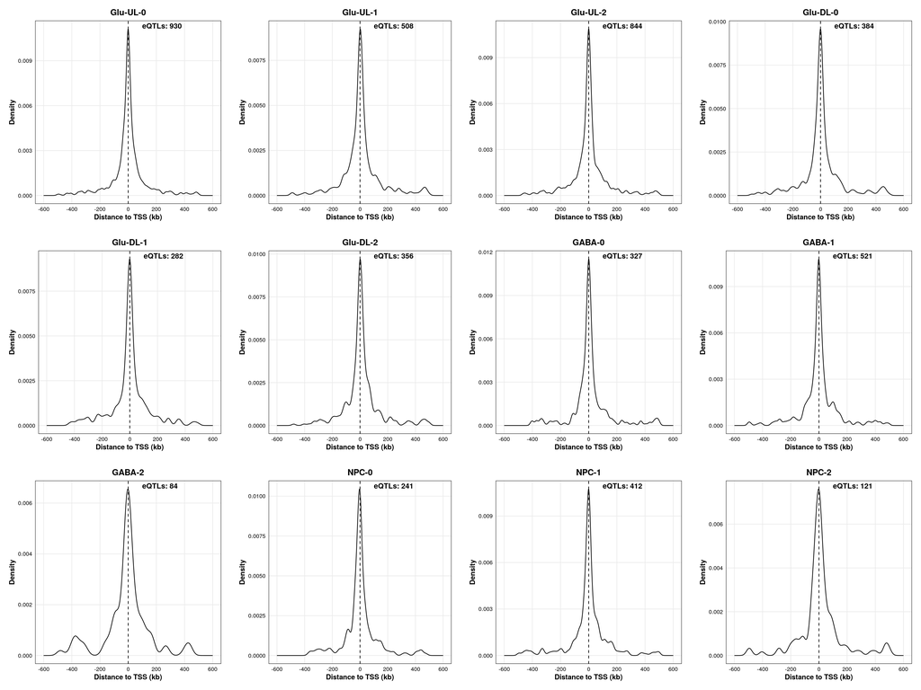

##### Combined

- Showing plots for geno PCs = 4, Exp PCs = `expPC_map`, norm method = ‘quantile’

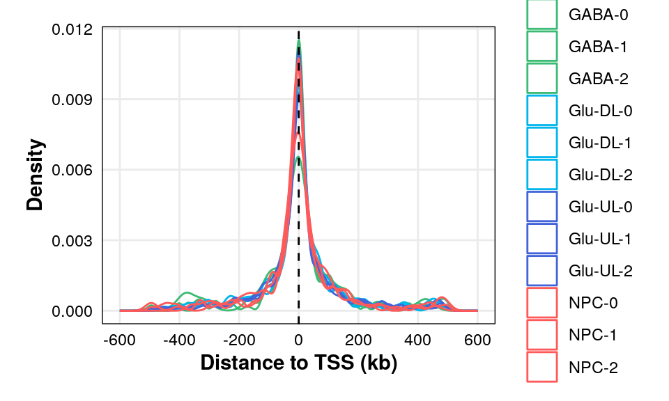

#### Counts

- Showing plots for geno PCs = 4, Exp PCs = `expPC_map`, norm method = ‘quantile’

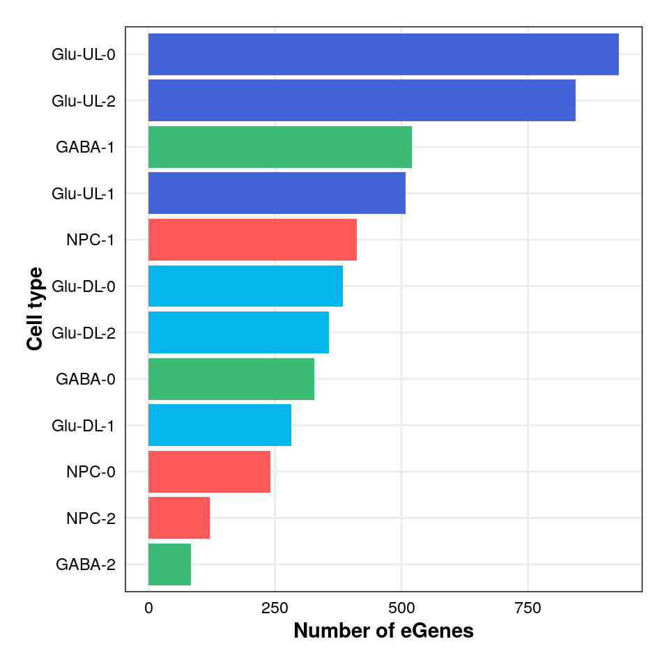

#### Independent

##### Counts

- Showing tables for geno PCs = 4, Exp PCs = `expPC_map`, norm method = ‘quantile’

Table 3. Independent eQTL counts per cell type

| Cell Type | Primary eQTL | Secondary eQTL | Tertiary eQTL |
| --- | --- | --- | --- |
| GABA-0 | 327 | 11 | 0 |
| GABA-1 | 521 | 13 | 0 |
| GABA-2 | 84 | 0 | 0 |
| Glu-DL-0 | 384 | 12 | 1 |
| Glu-DL-1 | 282 | 11 | 0 |
| Glu-DL-2 | 356 | 12 | 0 |
| Glu-UL-0 | 930 | 41 | 0 |
| Glu-UL-1 | 508 | 16 | 0 |
| Glu-UL-2 | 844 | 29 | 0 |
| NPC-0 | 241 | 8 | 0 |
| NPC-1 | 412 | 13 | 0 |
| NPC-2 | 121 | 4 | 0 |

##### Distance from TSS

- Showing tables for geno PCs = 4, Exp PCs = `expPC_map`, norm method = ‘quantile’

Table 4. Median TSS distances (kb) for independent eQTLs per cell type

| Cell Type | Primary eQTL | Secondary eQTL | Tertiary eQTL |
| --- | --- | --- | --- |
| GABA-0 | 27 | 94 | 0 |
| GABA-1 | 32 | 33 | 0 |
| GABA-2 | 46 | 0 | 0 |
| Glu-DL-0 | 34 | 87 | 354 |
| Glu-DL-1 | 35 | 99 | 0 |
| Glu-DL-2 | 34 | 52 | 0 |
| Glu-UL-0 | 32 | 38 | 0 |
| Glu-UL-1 | 37 | 190 | 0 |
| Glu-UL-2 | 32 | 69 | 0 |
| NPC-0 | 32 | 186 | 0 |
| NPC-1 | 32 | 20 | 0 |
| NPC-2 | 38 | 284 | 0 |

### Combined

#### Shared

- Showing plots for geno PCs = 4, Exp PCs = `expPC_map_L1` or `expPC_map_L2`, norm method = ‘quantile’

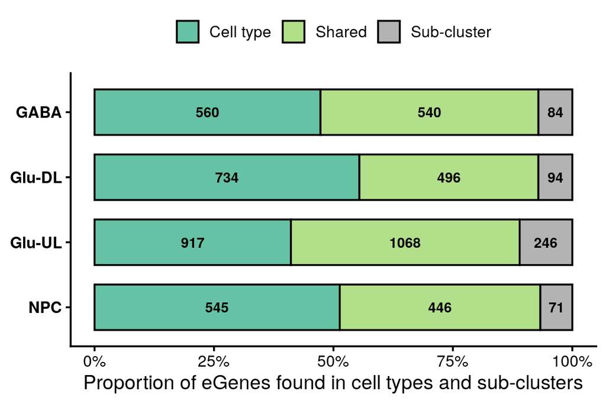

#### Counts CT

- Showing counts for geno PCs = 4, Exp PCs = `expPC_map_all`, norm method = ‘quantile’

| cell_type | total_sig_eqtl | unique_eQTL | unique_eGenes | top_eQTL |
| --- | --- | --- | --- | --- |
| Glu-UL | 1985 | 1985 | 1985 | 1985 |
| Glu-DL | 1230 | 1230 | 1230 | 1230 |
| GABA | 1100 | 1100 | 1100 | 1100 |
| NPC | 991 | 991 | 991 | 991 |
| MG | 62 | 62 | 62 | 62 |
| OPC | 115 | 115 | 115 | 115 |
| Endo-Peri | 112 | 112 | 112 | 112 |
| Glu-UL-0 | 930 | 930 | 930 | 930 |
| Glu-UL-1 | 508 | 508 | 508 | 508 |
| Glu-UL-2 | 844 | 844 | 844 | 844 |

[output cut: 10 more lines]

#### Counts All

- Showing counts for geno PCs = 4, Exp PCs = `expPC_map_all`, norm method = ‘quantile’

| total_sig_eqtl | unique_eGenes | unique_eQTL |
| --- | --- | --- |
| 10605 | 3121 | 6844 |